# Case 2

Mel Schwan

8/8/2019

## Case Study II: Using Data Science to Define Data Science

## Due Date: August 17, 2019

DDSAnalytics is an analytics company that specializes in talent management solutions for Fortune 100 companies. Talent management is defined as the iterative process of developing and retaining employees. It may include workforce planning, employee training programs, identifying high-potential employees and reducing/preventing voluntary employee turnover (attrition). To gain a competitive edge over its competition, DDSAnalytics is planning to leverage data science for talent management. The executive leadership has identified predicting employee turnover as its first application of data science for talent management. Before the business green lights the project, they have tasked your data science team to conduct an analysis of existing employee data.

This is a youtube video presention to the Frito Layes company discussing the data and it’s potential. https://youtu.be/RFpn13B5Xn0

### Deliverable

In using data science to define data science, we need to keep in mind reproducibility. To this end, your project markdown code should be committed and pushed to GitHub. The deliverable is a link to the GitHub repository where the markdown code resides.

We will provide the predication of the attriction value for each employee in the “CaseStudy2CompSet No Attrition.csv” file. We are to sort the employee numbers and write to my “Case2PredictionsSchwan Attrition.csv”.

#Load the supplied datasets and evaluate

```r
employee_df<-read.csv("./WA_Fn-UseC_-HR-Employee-Attrition.csv")
dim(employee_df)
```

```
## [1] 1470   35
```

```r
car::some(employee_df)
```

```
##      Age Attrition    BusinessTravel DailyRate             Department
## 99    58        No     Travel_Rarely       682                  Sales
## 578   37        No     Travel_Rarely       571 Research & Development
## 678   49        No     Travel_Rarely       527 Research & Development
## 682   38        No     Travel_Rarely      1333 Research & Development
## 918   34        No     Travel_Rarely       131                  Sales
## 961   41        No Travel_Frequently      1018                  Sales
## 967   58       Yes     Travel_Rarely       601 Research & Development
## 1013  31       Yes Travel_Frequently       667                  Sales
## 1039  48        No     Travel_Rarely      1221                  Sales
## 1075  33        No     Travel_Rarely       516 Research & Development
##      DistanceFromHome Education   EducationField EmployeeCount
## 99                 10         4          Medical             1
## 578                10         1    Life Sciences             1
## 678                 8         2            Other             1
```

[output cut: 84 more lines]

```r
#Make a copy of employee_df for Modeling
retention_set = employee_df
skim(retention_set)
```

```
## Skim summary statistics
##  n obs: 1470
##  n variables: 35
##
## -- Variable type:factor --------------------------------------------------------------------------------------------------------------------------------------------
##        variable missing complete    n n_unique
##       Attrition       0     1470 1470        2
##  BusinessTravel       0     1470 1470        3
##      Department       0     1470 1470        3
##  EducationField       0     1470 1470        6
##          Gender       0     1470 1470        2
##         JobRole       0     1470 1470        9
##   MaritalStatus       0     1470 1470        3
##          Over18       0     1470 1470        1
##        OverTime       0     1470 1470        2
##                              top_counts ordered
##               No: 1233, Yes: 237, NA: 0   FALSE
##    Tra: 1043, Tra: 277, Non: 150, NA: 0   FALSE
##      Res: 961, Sal: 446, Hum: 63, NA: 0   FALSE
##  Lif: 606, Med: 464, Mar: 159, Tec: 132   FALSE
##               Mal: 882, Fem: 588, NA: 0   FALSE
##  Sal: 326, Res: 292, Lab: 259, Man: 145   FALSE
##     Mar: 673, Sin: 470, Div: 327, NA: 0   FALSE
##                          Y: 1470, NA: 0   FALSE
##               No: 1054, Yes: 416, NA: 0   FALSE
##
## -- Variable type:integer -------------------------------------------------------------------------------------------------------------------------------------------
##                  variable missing complete    n     mean      sd   p0
##                       Age       0     1470 1470    36.92    9.14   18
##                 DailyRate       0     1470 1470   802.49  403.51  102
##          DistanceFromHome       0     1470 1470     9.19    8.11    1
##                 Education       0     1470 1470     2.91    1.02    1
##             EmployeeCount       0     1470 1470     1       0       1
##            EmployeeNumber       0     1470 1470  1024.87  602.02    1
##   EnvironmentSatisfaction       0     1470 1470     2.72    1.09    1
##                HourlyRate       0     1470 1470    65.89   20.33   30
##            JobInvolvement       0     1470 1470     2.73    0.71    1
##                  JobLevel       0     1470 1470     2.06    1.11    1
##           JobSatisfaction       0     1470 1470     2.73    1.1     1
##             MonthlyIncome       0     1470 1470  6502.93 4707.96 1009
```

[output cut: 26 more lines]

```
##  2911     4919    8379    19999 ▇▇▃▂▁▁▁▂
##  8047    14235.5 20461.5  26999 ▇▇▇▇▇▇▇▆
##     1        2       4        9 ▇▂▂▂▁▁▁▁
##    12       14      18       25 ▇▇▃▃▂▂▂▁
##     3        3       3        4 ▇▁▁▁▁▁▁▂
##     2        3       4        4 ▅▁▅▁▁▇▁▇
##    80       80      80       80 ▁▁▁▇▁▁▁▁
##     0        1       1        3 ▇▁▇▁▁▂▁▁
##     6       10      15       40 ▅▇▂▂▂▁▁▁
##     2        3       3        6 ▁▁▇▇▁▂▂▁
##     2        3       3        4 ▁▁▃▁▁▇▁▂
##     3        5       9       40 ▇▅▁▁▁▁▁▁
##     2        3       7       18 ▇▃▁▅▁▁▁▁
##     0        1       3       15 ▇▂▁▁▁▁▁▁
##     2        3       7       17 ▇▃▁▃▁▁▁▁
```

```r
#Change attrition to numeric

comp_set<-read_csv("./CaseStudy2CompSet No Attrition.csv")
comp_set_study<-read_csv("./CaseStudy2-data.csv")
comp_set_nosalary<-read_xlsx("./CaseStudy2CompSet No Salary.xlsx")
skim(comp_set)
```

```
## Skim summary statistics
##  n obs: 300
##  n variables: 35
##
## -- Variable type:character -----------------------------------------------------------------------------------------------------------------------------------------
##        variable missing complete   n min max empty n_unique
##  BusinessTravel       0      300 300  10  17     0        3
##      Department       0      300 300   5  22     0        3
##  EducationField       0      300 300   5  16     0        6
##          Gender       0      300 300   4   6     0        2
##         JobRole       0      300 300   7  25     0        9
##   MaritalStatus       0      300 300   6   8     0        3
##          Over18       0      300 300   1   1     0        1
##        OverTime       0      300 300   2   3     0        2
##
## -- Variable type:numeric -------------------------------------------------------------------------------------------------------------------------------------------
##                  variable missing complete   n     mean      sd   p0
##                       Age       0      300 300    37.86    9.61   19
##                 DailyRate       0      300 300   784.77  404.13  102
##          DistanceFromHome       0      300 300     9.26    8.54    1
##                 Education       0      300 300     2.97    1.01    1
##             EmployeeCount       0      300 300     1       0       1
##            EmployeeNumber       0      300 300  1020.9   584.4     2
##   EnvironmentSatisfaction       0      300 300     2.73    1.08    1
##                HourlyRate       0      300 300    66.07   20.2    30
##                        ID       0      300 300  1320.5    86.75 1171
##            JobInvolvement       0      300 300     2.74    0.75    1
##                  JobLevel       0      300 300     2.2     1.24    1
##           JobSatisfaction       0      300 300     2.77    1.08    1
##             MonthlyIncome       0      300 300  7103.4  5298.5  1232
##               MonthlyRate       0      300 300 14499.4  7144.13 2097
##        NumCompaniesWorked       0      300 300     2.55    2.35    0
##         PercentSalaryHike       0      300 300    15.17    3.63   11
##         PerformanceRating       0      300 300     3.15    0.36    3
##  RelationshipSatisfaction       0      300 300     2.8     1.03    1
##             StandardHours       0      300 300    80       0      80
##          StockOptionLevel       0      300 300     0.78    0.87    0
##         TotalWorkingYears       0      300 300    12.44    8.58    0
##     TrainingTimesLastYear       0      300 300     2.68    1.29    0
##           WorkLifeBalance       0      300 300     2.75    0.69    1
```

[output cut: 17 more lines]

```
##  3033.75  5208.5  9749.75 19973 ▇▇▃▂▁▁▁▂
##  8419.75 15091   20329.75 26914 ▇▅▆▅▆▇▇▅
##     1        2       4        9 ▇▂▂▂▁▁▁▁
##    12       14      18       25 ▇▆▅▃▁▂▂▁
##     3        3       3        4 ▇▁▁▁▁▁▁▂
##     2        3       4        4 ▃▁▃▁▁▇▁▆
##    80       80      80       80 ▁▁▁▇▁▁▁▁
##     0        1       1        3 ▇▁▆▁▁▂▁▁
##     6       10      18       38 ▃▇▆▃▂▂▁▁
##     2        2       3        6 ▁▁▇▅▁▂▁▁
##     2        3       3        4 ▁▁▃▁▁▇▁▁
##     3        5      10       37 ▇▇▃▁▁▁▁▁
##     2        3       7       18 ▇▃▁▅▁▁▁▁
##     0        1       3       15 ▇▂▁▁▁▁▁▁
##     2        3       7       17 ▇▃▁▃▁▁▁▁
```

```r
skim(comp_set_study)
```

```
## Skim summary statistics
##  n obs: 870
##  n variables: 36
##
## -- Variable type:character -----------------------------------------------------------------------------------------------------------------------------------------
##        variable missing complete   n min max empty n_unique
##       Attrition       0      870 870   2   3     0        2
##  BusinessTravel       0      870 870  10  17     0        3
##      Department       0      870 870   5  22     0        3
##  EducationField       0      870 870   5  16     0        6
##          Gender       0      870 870   4   6     0        2
##         JobRole       0      870 870   7  25     0        9
##   MaritalStatus       0      870 870   6   8     0        3
##          Over18       0      870 870   1   1     0        1
##        OverTime       0      870 870   2   3     0        2
##
## -- Variable type:numeric -------------------------------------------------------------------------------------------------------------------------------------------
##                  variable missing complete   n     mean      sd   p0
##                       Age       0      870 870    36.83    8.93   18
##                 DailyRate       0      870 870   815.23  401.12  103
##          DistanceFromHome       0      870 870     9.34    8.14    1
##                 Education       0      870 870     2.9     1.02    1
##             EmployeeCount       0      870 870     1       0       1
##            EmployeeNumber       0      870 870  1029.83  604.79    1
##   EnvironmentSatisfaction       0      870 870     2.7     1.1     1
##                HourlyRate       0      870 870    65.61   20.13   30
##                        ID       0      870 870   435.5   251.29    1
##            JobInvolvement       0      870 870     2.72    0.7     1
##                  JobLevel       0      870 870     2.04    1.09    1
##           JobSatisfaction       0      870 870     2.71    1.11    1
##             MonthlyIncome       0      870 870  6390.26 4597.7  1081
##               MonthlyRate       0      870 870 14325.62 7108.38 2094
##        NumCompaniesWorked       0      870 870     2.73    2.52    0
##         PercentSalaryHike       0      870 870    15.2     3.68   11
##         PerformanceRating       0      870 870     3.15    0.36    3
##  RelationshipSatisfaction       0      870 870     2.71    1.1     1
##             StandardHours       0      870 870    80       0      80
##          StockOptionLevel       0      870 870     0.78    0.86    0
##         TotalWorkingYears       0      870 870    11.05    7.51    0
##     TrainingTimesLastYear       0      870 870     2.83    1.27    0
```

[output cut: 18 more lines]

```
##  2839.5   4945.5  8182    19999 ▇▇▃▂▁▁▁▁
##  8092    14074.5 20456.25 26997 ▆▇▇▇▇▆▇▆
##     1        2       4        9 ▇▂▂▂▁▁▁▁
##    12       14      18       25 ▇▇▃▃▁▂▂▁
##     3        3       3        4 ▇▁▁▁▁▁▁▂
##     2        3       4        4 ▅▁▅▁▁▇▁▇
##    80       80      80       80 ▁▁▁▇▁▁▁▁
##     0        1       1        3 ▇▁▇▁▁▂▁▁
##     6       10      15       40 ▅▇▂▂▁▁▁▁
##     2        3       3        6 ▁▁▇▇▁▂▂▁
##     2        3       3        4 ▁▁▃▁▁▇▁▂
##     3        5      10       40 ▇▅▁▁▁▁▁▁
##     2        3       7       18 ▇▂▁▅▁▁▁▁
##     0        1       3       15 ▇▂▁▁▁▁▁▁
##     2        3       7       17 ▇▂▁▃▁▁▁▁
```

```r
skim(comp_set_nosalary)
```

```
## Skim summary statistics
##  n obs: 300
##  n variables: 35
##
## -- Variable type:character -----------------------------------------------------------------------------------------------------------------------------------------
##        variable missing complete   n min max empty n_unique
##       Attrition       0      300 300   2   3     0        2
##  BusinessTravel       0      300 300  10  17     0        3
##      Department       0      300 300   5  22     0        3
##  EducationField       0      300 300   5  16     0        6
##          Gender       0      300 300   4   6     0        2
##         JobRole       0      300 300   7  25     0        9
##   MaritalStatus       0      300 300   6   8     0        3
##          Over18       0      300 300   1   1     0        1
##        OverTime       0      300 300   2   3     0        2
##
## -- Variable type:numeric -------------------------------------------------------------------------------------------------------------------------------------------
##                  variable missing complete   n     mean      sd   p0
##                       Age       0      300 300    36.27    9.21   18
##                 DailyRate       0      300 300   783.25  409.68  105
##          DistanceFromHome       0      300 300     8.7     7.57    1
##                 Education       0      300 300     2.89    1.04    1
##             EmployeeCount       0      300 300     1       0       1
##            EmployeeNumber       0      300 300  1014.43  613.08    7
##   EnvironmentSatisfaction       0      300 300     2.77    1.09    1
##                HourlyRate       0      300 300    66.52   21.08   30
##                        ID       0      300 300  1020.5    86.75  871
##            JobInvolvement       0      300 300     2.74    0.7     1
##                  JobLevel       0      300 300     2       1.01    1
##           JobSatisfaction       0      300 300     2.75    1.09    1
##               MonthlyRate       0      300 300 14090.51 7136.51 2122
##        NumCompaniesWorked       0      300 300     2.74    2.58    0
##         PercentSalaryHike       0      300 300    15.28    3.66   11
##         PerformanceRating       0      300 300     3.16    0.37    3
##  RelationshipSatisfaction       0      300 300     2.64    1.06    1
##             StandardHours       0      300 300    80       0      80
##          StockOptionLevel       0      300 300     0.83    0.82    0
##         TotalWorkingYears       0      300 300    10.78    7.62    0
##     TrainingTimesLastYear       0      300 300     2.82    1.33    0
##           WorkLifeBalance       0      300 300     2.72    0.71    1
```

[output cut: 16 more lines]

```
##     2        3       4        4 ▅▁▅▁▁▇▁▇
##  7778.5  13508   20464.25 26999 ▇▇▇▇▇▆▇▆
##     1        2       4        9 ▇▂▂▂▁▁▁▁
##    12.75    14      18       25 ▆▇▃▂▂▂▂▁
##     3        3       3        4 ▇▁▁▁▁▁▁▂
##     2        3       4        4 ▅▁▇▁▁▇▁▇
##    80       80      80       80 ▁▁▁▇▁▁▁▁
##     0        1       1        3 ▇▁▇▁▁▂▁▁
##     6        9      14       40 ▅▇▂▂▁▁▁▁
##     2        3       3        6 ▁▁▇▇▁▂▂▁
##     2        3       3        4 ▁▁▃▁▁▇▁▁
##     3        5       9       33 ▇▇▃▁▁▁▁▁
##     2        3       7       16 ▇▃▁▃▁▁▁▁
##     0        1       3       15 ▇▂▁▁▁▁▁▁
##     2        3       7       15 ▆▇▂▃▂▁▁▁
```

```r
#Change Attrition to numeric
employee_df[, c(2)] <- sapply(employee_df[, c(2)], as.numeric)
#Look for any empty cells
sum(is.na(retention_set))
```

```
## [1] 0
```

```r
sum(is.na(comp_set))
```

```
## [1] 0
```

```r
sum(is.na(comp_set_study))
```

```
## [1] 0
```

```r
sum(is.na(comp_set_nosalary))
```

```
## [1] 0
```

#Get information on simple data statistics

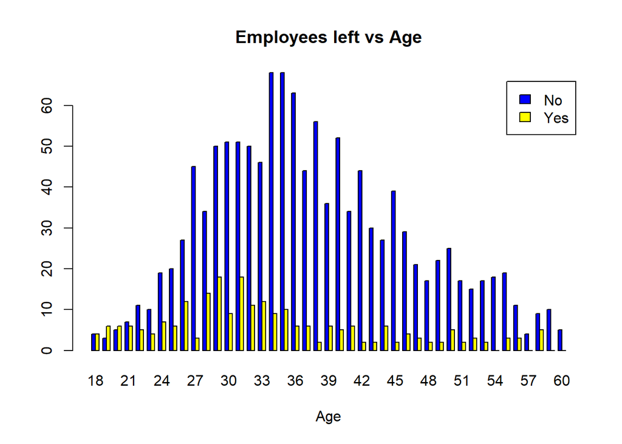

```r
#Plot some data comparisons

plottable1=table(retention_set$Attrition,retention_set$Age)
plottable3=table(retention_set$Attrition,retention_set$YearsSinceLastPromotion)
plottable4=table(retention_set$Attrition,retention_set$JobInvolvement)
plottable5=table(retention_set$Attrition,retention_set$PercentSalaryHike)
plottable6=table(retention_set$Attrition,retention_set$PerformanceRating)
plottable7=table(retention_set$Attrition,retention_set$YearsInCurrentRole)
plottable8=table(retention_set$Attrition,retention_set$YearsAtCompany)


barplot(plottable1, main="Employees left vs Age", xlab="Age",col=c("Blue","Yellow"),legend=rownames(plottable1),beside = TRUE)
```

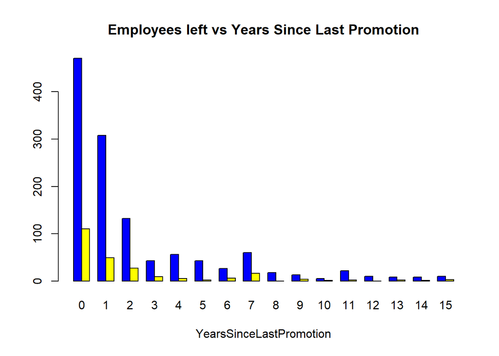

```r
barplot(plottable3, main="Employees left vs Years Since Last Promotion", xlab="YearsSinceLastPromotion", col=c("Blue","Yellow"),beside = TRUE)
```

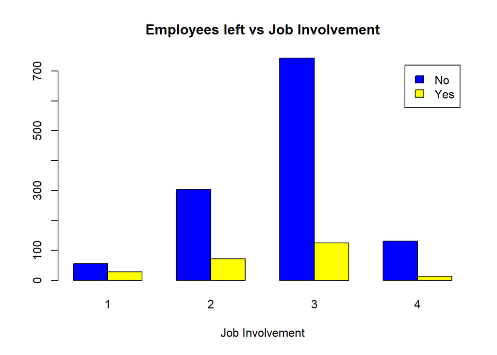

```r
barplot(plottable4, main="Employees left vs Job Involvement", xlab="Job Involvement", col=c("Blue","Yellow"),legend=rownames(plottable1),beside = TRUE)
```

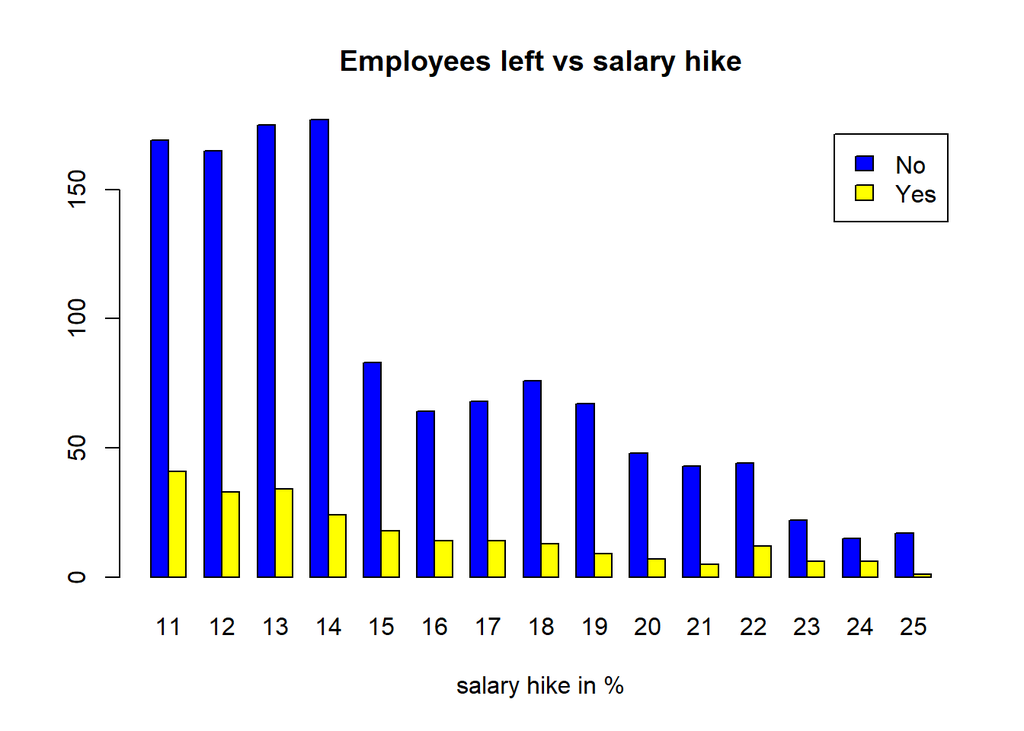

```r
barplot(plottable5, main="Employees left vs salary hike", xlab="salary hike in %", col=c("Blue","Yellow"),legend=rownames(plottable1),beside = TRUE)
```

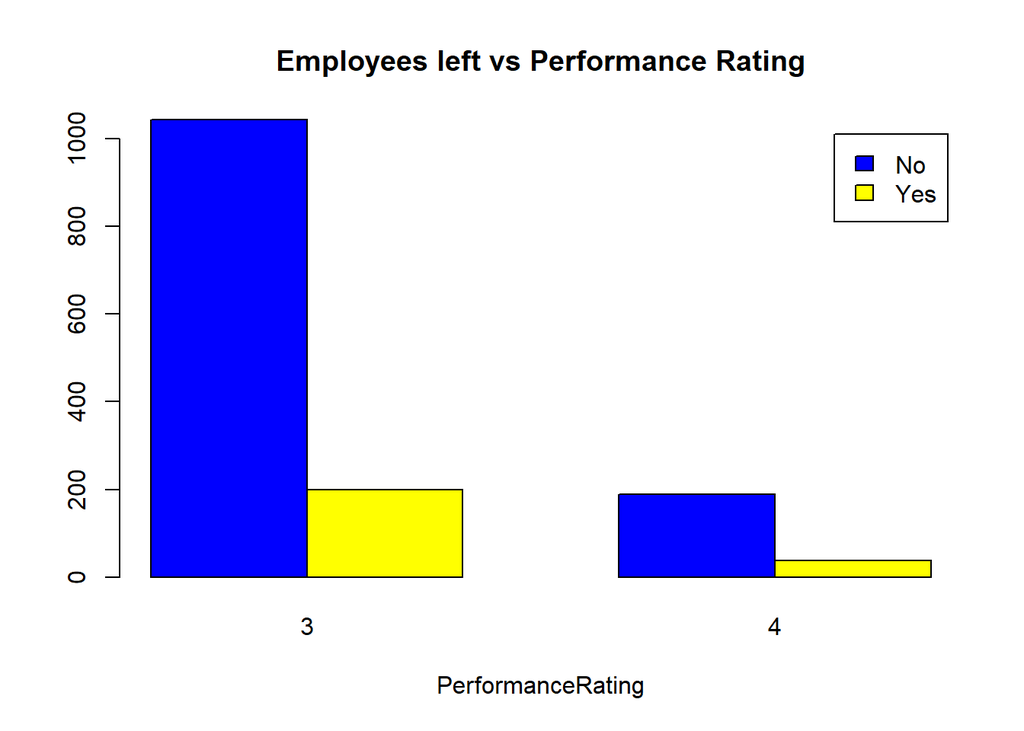

```r
barplot(plottable6, main="Employees left vs Performance Rating", xlab="PerformanceRating",col=c("Blue","Yellow"),legend=rownames(plottable1),beside = TRUE)
```